# Vázquez_Zambrano_Diego_PEC3_ML

Algoritmo Support Vector Machine

El algoritmo Support Vector Machine (SVM) es un método de aprendizaje supervisado utilizado en problemas clasificación y regresión. SVM busca encontrar el hiperplano que mejor separa los datos de diferentes clases en un espacio de alta dimensión. El funcionamiento de SVM se basa en la idea de encontrar el hiperplano que maximiza la distancia entre los puntos de datos de diferentes clases, también conocido como el margen. Los puntos de datos que se encuentran más cerca del hiperplano se denominan vectores de soporte, de ahí el nombre del algoritmo.

Las características principales del algoritmo SVM son: SVM es un algoritmo de aprendizaje supervisado que se utiliza para la clasificación y regresión de datos. SVM busca encontrar el hiperplano que mejor separa los datos en diferentes clases. El hiperplano es elegido de tal manera que maximiza la distancia entre los puntos de datos más cercanos de cada clase, lo que se conoce como margen. SVM es un algoritmo muy efectivo para clasificar datos en conjuntos de alta dimensionalidad. SVM es capaz de manejar datos no lineales utilizando diferentes funciones de kernel.

A continuación, se presenta una tabla que resume las fortalezas y debilidades de SVM:

Fortalezas:

1. Efectivo en conjuntos de datos de alta dimensionalidad
2. Capaz de manejar datos no lineales utilizando diferentes funciones de kernel
3. Puede manejar múltiples clases de datos
4. SVM tiene una buena capacidad de generalización
5. SVM es resistente a los valores atípicos

Debilidades:

1. No es adecuado para conjuntos de datos muy grandes
2. Sensible a la selección de parámetros
3. Requiere un preprocesamiento cuidadoso de los datos
4. Puede ser computacionalmente costoso entrenar el modelo
5. No proporciona una probabilidad de clasificación directa

```python
import pandas as pd
import numpy as np
import matplotlib.pyplot as plt

# Leer el archivo CSV
df=pd.read_csv('D:/dataset_t3_1.csv')

print(df.columns)

# Eliminar variables no informativas
df = df.drop(['Image'], axis=1)

# Comprobar si hay valores faltantes
if df.isnull().values.any():
    # Calcular el porcentaje de valores faltantes en cada variable
    missing_percentages = df.isnull().sum() / len(df) * 100
    print("Porcentaje de valores faltantes en cada variable:")
    print(missing_percentages)

    # Eliminar variables con porcentaje de valores faltantes igual o mayor al 20%
    df = df.dropna(thresh=len(df)*0.8, axis=1)
    print("Variables eliminadas:")
    print(list(set(missing_percentages[missing_percentages >= 20].index)))

    # Eliminar imágenes con valores faltantes
    df = df.dropna()
```

```
Index(['Image', 'Mean', 'Variance', 'Standard.Deviation', 'Entropy',
       'Skewness', 'Kurtosis', 'Contrast', 'Energy', 'ASM', 'Homogeneity',
       'Dissimilarity', 'Correlation', 'Coarseness', 'PSNR', 'SSIM', 'MSE',
       'DC', 'clase'],
      dtype='object')
Porcentaje de valores faltantes en cada variable:
Mean                   0.000000
Variance               0.000000
Standard.Deviation     0.000000
Entropy                0.000000
Skewness              22.445255
Kurtosis              22.445255
Contrast               0.000000
Energy                 0.000000
ASM                    0.000000
Homogeneity            0.000000
Dissimilarity          0.000000
Correlation            0.000000
Coarseness             0.000000
PSNR                   0.000000
SSIM                  22.445255
MSE                    0.000000
DC                     5.961071
clase                  0.000000
dtype: float64
Variables eliminadas:
['Kurtosis', 'SSIM', 'Skewness']
```

```
              Mean     Variance  Standard.Deviation      Entropy     Contrast  \
count  1546.000000  1546.000000         1546.000000  1546.000000  1546.000000
mean      3.323295   401.125634           15.106902     0.945917    61.895655
std       5.466482   556.738341           13.153671     0.096214    77.290750
min       0.000000     0.000000            0.000000     0.530684     0.000000
25%       0.082703    13.463382            3.669234     0.946582     7.890717
50%       1.027420   156.890324           12.525568     0.985381    36.877493
75%       3.944096   584.191571           24.170047     0.998680    83.837169
max      31.031021  3345.853590           57.843354     1.000000   743.368131

            Energy          ASM  Homogeneity  Dissimilarity  Correlation  \
count  1546.000000  1546.000000  1546.000000    1546.000000  1546.000000
mean      0.967014     0.938762     0.978442       0.580709     0.888728
std       0.060400     0.107307     0.037638       0.791625     0.116067
min       0.695889     0.484262     0.811102       0.000000    -0.000035
25%       0.968655     0.938293     0.978690       0.053801     0.850080
50%       0.991484     0.983040     0.993697       0.289592     0.919154
75%       0.999233     0.998466     0.999423       0.713511     0.963400
max       1.000000     1.000000     1.000000       5.604428     1.000000

          Coarseness         PSNR          MSE           DC        clase
count   1.546000e+03  1546.000000  1546.000000  1546.000000  1546.000000
mean   7.458341e-155    69.788729     0.038760     0.320465     0.937257
std     0.000000e+00    14.180364     0.051930     0.312112     0.242578
min    7.458341e-155    53.378482     0.000017     0.000000     0.000000
25%    7.458341e-155    62.231101     0.009705     0.000000     1.000000
50%    7.458341e-155    65.402806     0.022387     0.247692     1.000000
75%    7.458341e-155    70.044243     0.043016     0.599091     1.000000
max    7.458341e-155   128.882059     0.298698     0.957969     1.000000
<class 'pandas.core.frame.DataFrame'>
Int64Index: 1546 entries, 0 to 1643
Data columns (total 15 columns):
 #   Column              Non-Null Count  Dtype
---  ------              --------------  -----
 0   Mean                1546 non-null   float64
 1   Variance            1546 non-null   float64
 2   Standard.Deviation  1546 non-null   float64
 3   Entropy             1546 non-null   float64
 4   Contrast            1546 non-null   float64
 5   Energy              1546 non-null   float64
```

[output cut: 64 more lines]

```
Mean               -0.171909
Variance           -0.091415
Standard.Deviation -0.092035
Entropy             0.236299
Contrast           -0.139715
Energy              0.236770
ASM                 0.235975
Homogeneity         0.211503
Dissimilarity      -0.184592
Correlation         0.117905
Coarseness               NaN
PSNR               -0.066223
MSE                -0.221783
DC                  0.265744
clase               1.000000
```

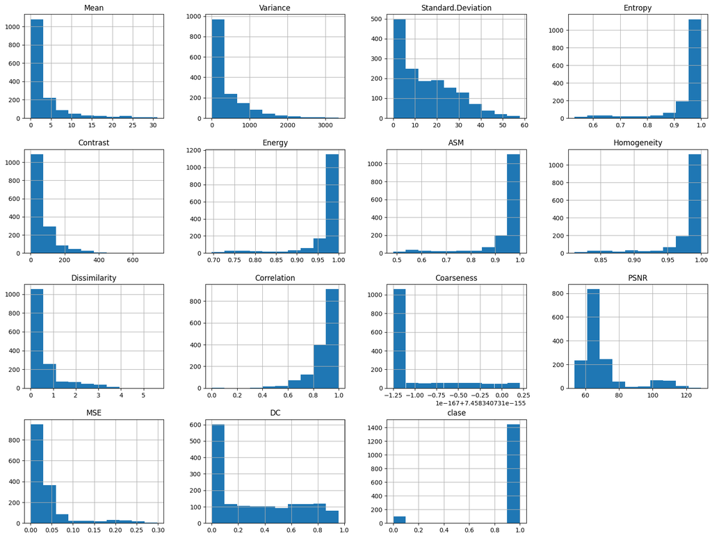

```python
# Obtener estadísticas descriptivas de las variables numéricas
print(df.describe())
# Obtener información sobre el tipo de datos y la cantidad de valores no nulos en cada variable
print(df.info())
# Calcular la matriz de correlación entre las variables numéricas
print(df.corr())
# Crear histogramas de las variables numéricas
df.hist(bins=10, figsize=(20,15))
plt.show()
```

```
         Mean                                                              \
        count      mean       std      min       25%       50%        75%
clase
0        97.0  6.954205  7.793813  0.02652  0.345016  2.106567  12.572342
1      1449.0  3.080232  5.187943  0.00000  0.071823  0.993073   3.649307

                 Variance              ...       MSE                DC  \
             max    count        mean  ...       75%       max   count
clase                                  ...
0      30.858765     97.0  597.767226  ...  0.183003  0.298698    97.0
1      31.031021   1449.0  387.961911  ...  0.041233  0.283906  1449.0


           mean       std  min       25%       50%      75%       max
clase
0      0.000000  0.000000  0.0  0.000000  0.000000  0.00000  0.000000
1      0.341918  0.310804  0.0  0.021053  0.285714  0.62089  0.957969

[2 rows x 112 columns]
```

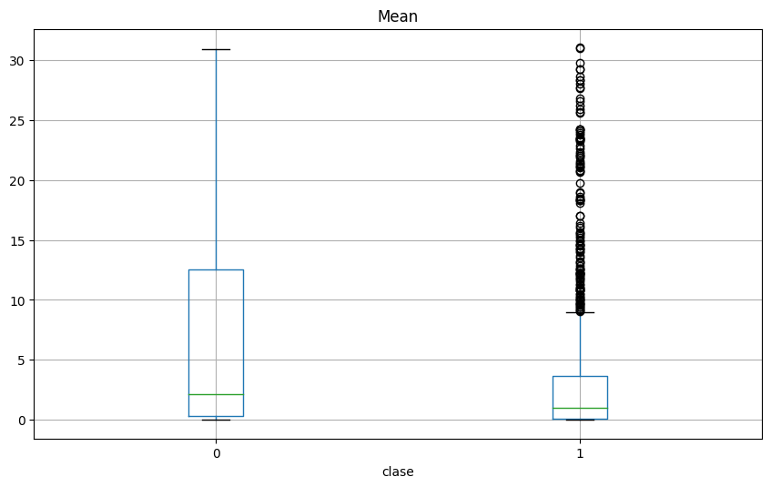

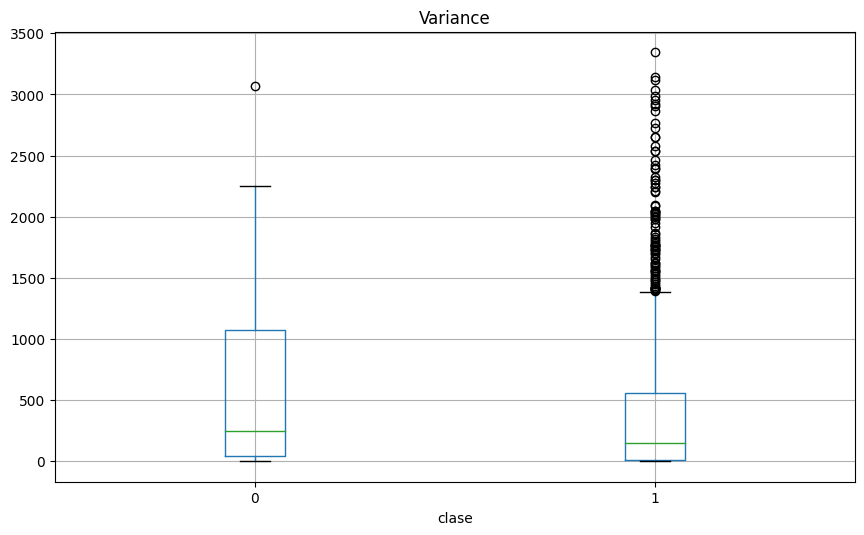

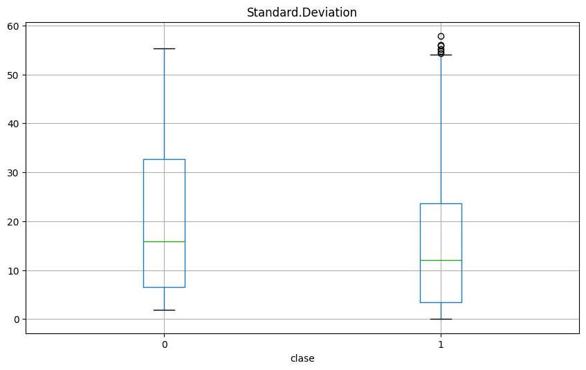

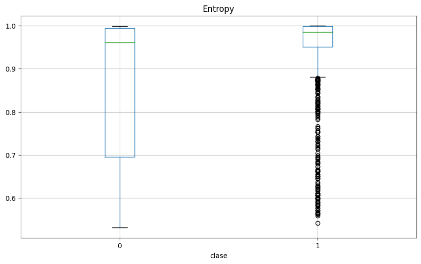

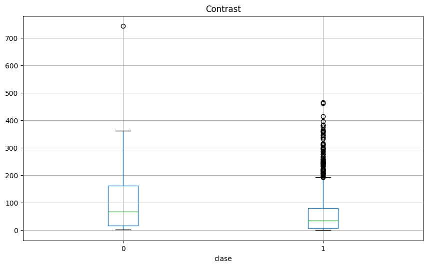

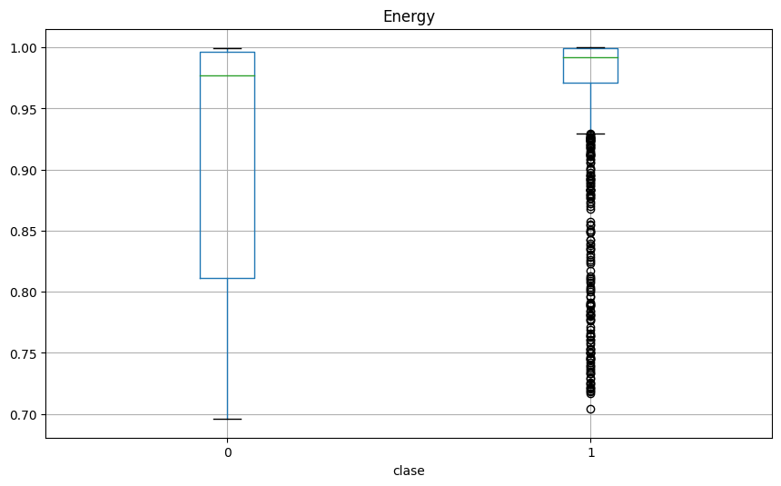

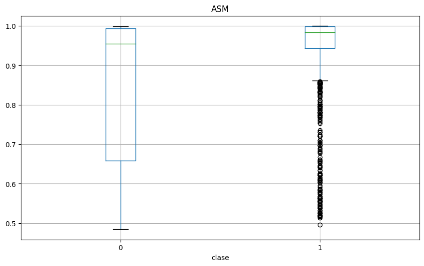

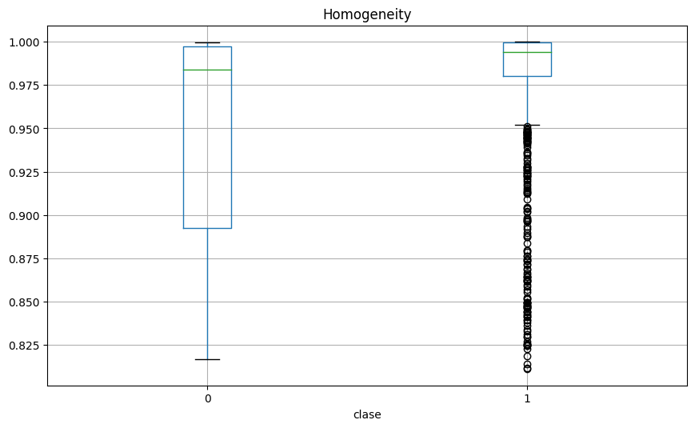

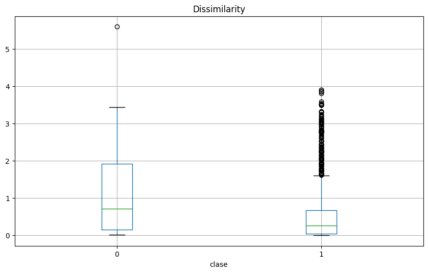

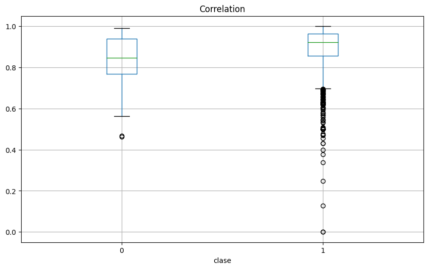

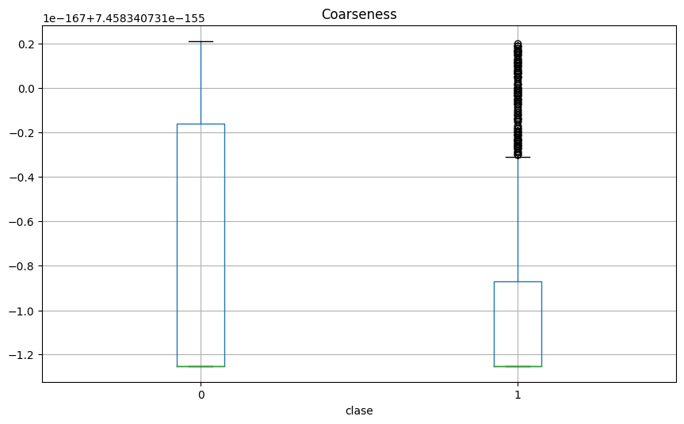

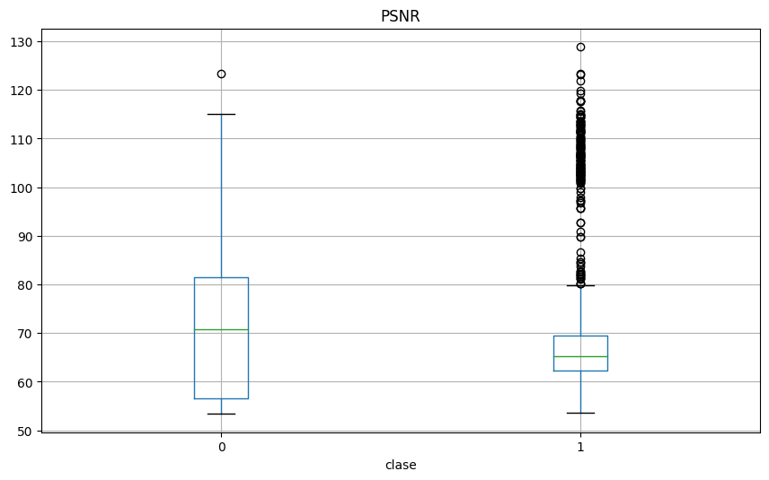

[2 more figures not shown]

```
1    1449
0      97
Name: clase, dtype: int64
```

```python
# Agrupar los datos por clase y obtener estadísticas descriptivas de cada variable numérica
grouped = df.groupby('clase')
print(grouped.describe())
# Crear diagramas de caja y bigotes para cada variable numérica, separados por clase
for column in df.columns:
    if column != 'clase':
        df.boxplot(column=column, by='clase', figsize=(10,6))
        plt.title(column)
        plt.suptitle('')
        plt.show()
# Obtener el tamaño muestral de cada clase
print(df['clase'].value_counts())
```